# Predicción de las ventas trimestrales de Apple

Marcos Barragán

16/11/2020

## Objetivo

El objetivo de la práctica es predecir los resultados de las ventas de Apple en los trimestres de 2017 y 2018 a partir de los datos de ventas trimestrales desde 2008.

### Desarrollo:

Cargamos el fichero de datos necesario para el desarrollo de la práctica. Este dataset consiste en dos columnas y 38 filas correspondientes a los ingresos de Apple en los diferentes trimestres desde 2008 hasta 2017.

```r
apple <- read.csv("IngresosApple.csv", sep = ";", dec = ",")

head(apple)
```

```
##   Trimestre Ingresos
## 1   Q2 2008     7980
## 2   Q3 2008     7561
## 3   Q4 2008    11520
## 4   Q1 2009    11880
## 5   Q2 2009     9084
## 6   Q3 2009     9734
```

Para poder tratar con los datos tenemos que pasar la primera columna del fichero a formato fecha. Los datos están codificados en forma trimestre - año, por lo que tenemos que hacerle entender al programa que queremos que los entienda como una fecha trimestral. Para ello usaremos *by = quarter* en la lectura de los datos:

```r
fechas <- seq(as.Date("2008/04/01"), as.Date("2017/09/30"), by = "quarter")

apple <- mutate(apple, fecha = fechas)

tail(apple)
```

```
##    Trimestre Ingresos      fecha
## 33   Q2 2016    50557 2016-04-01
## 34   Q3 2016    42358 2016-07-01
## 35   Q4 2016    46852 2016-10-01
## 36   Q1 2017    78351 2017-01-01
## 37   Q2 2017    52896 2017-04-01
## 38   Q3 2017    45408 2017-07-01
```

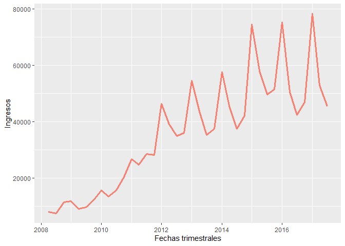

```r
ggplot(apple, aes(x = fecha, y = Ingresos)) +
  geom_line(color = 'Salmon', lwd = 1.2) +
  labs(x = 'Fechas trimestrales', y = "Ingresos")
```

A priori, vemos que no es estacionaria ni en media ni en varianza.

```r
xVentas <- xts(apple$Ingresos, order.by = as.Date(apple$fecha,"%Y/%m/%d"), frequency = 4)

xVentas <- to.quarterly(xVentas) #Le hacemos entender que son trimestres lo que estamos tomando.

head(xVentas)
```

```
##         xVentas.Open xVentas.High xVentas.Low xVentas.Close
## 2008 Q2         7980         7980        7980          7980
## 2008 Q3         7561         7561        7561          7561
## 2008 Q4        11520        11520       11520         11520
## 2009 Q1        11880        11880       11880         11880
## 2009 Q2         9084         9084        9084          9084
## 2009 Q3         9734         9734        9734          9734
```

```r
#Transform to zoo data (forecast package)

zVentas <- as.zoo(xVentas$xVentas.Close)


#Change name
names(zVentas) <- "Ventas"

head(zVentas)
```

```
##         Ventas
## 2008 Q2   7980
## 2008 Q3   7561
## 2008 Q4  11520
## 2009 Q1  11880
## 2009 Q2   9084
## 2009 Q3   9734
```

```r
tail(zVentas)
```

```
##         Ventas
## 2016 Q2  50557
## 2016 Q3  42358
## 2016 Q4  46852
## 2017 Q1  78351
## 2017 Q2  52896
## 2017 Q3  45408
```

Si representamos un gráfico en el que se muestren las ventas en función de los trimestres, obtendremos algo similar a:

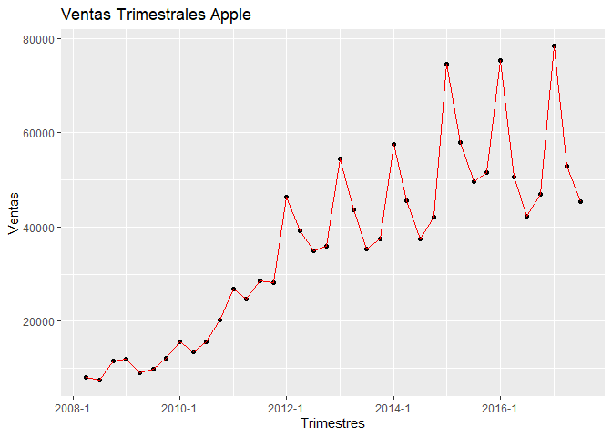

```r
df_new <- data.frame(value = as.vector(zVentas),
                     time = time(zVentas))

ggplot(df_new) +
  geom_point(aes(x = time, y = value)) +
  geom_line(aes(x = time,y = value), color = 'Red') +
  ylab("Ventas") +
  ggtitle("Ventas Trimestrales Apple") +
  xlab("Trimestres")
```

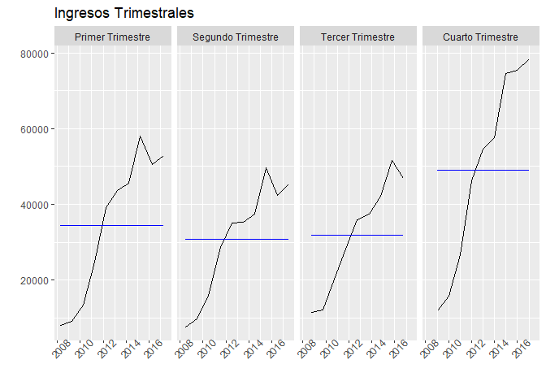

```r
tsVentas <- ts(coredata(zVentas), start = c(2008, 2), frequency = 4)

ggfreqplot(tsVentas, freq = 4, nrow = 1, facet.labeller = c("Primer Trimestre","Segundo Trimestre","Tercer Trimestre","Cuarto Trimestre")) +
  ggtitle("Ingresos Trimestrales") +
  theme(axis.text.x = element_text(angle = 45))
```

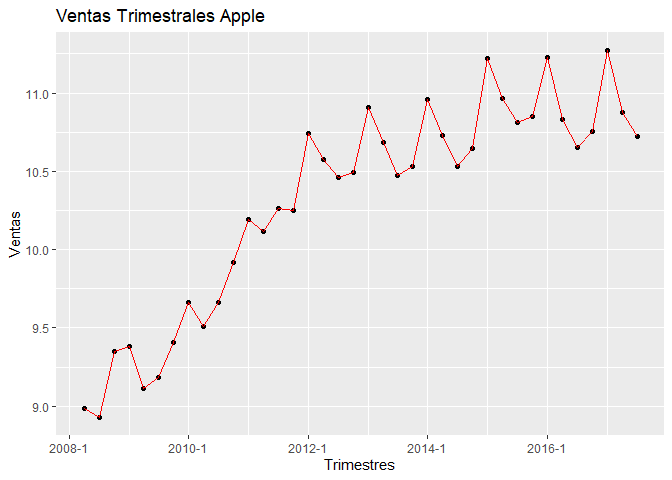

```r
zVentas_log <- log(zVentas)

df_new_log <- data.frame(value = as.vector(zVentas_log),
                     time = time(zVentas_log))

ggplot(df_new_log) +
  geom_point(aes(x = time, y = value)) +
  geom_line(aes(x = time,y = value), color = 'Red') +
  ylab("Ventas") +
  ggtitle("Ventas Trimestrales Apple") +
  xlab("Trimestres")
```

En este caso, la transformación logarítmica de los datos acentúa incluso más la subida entre 2009 y 2012, y suaviza las subidas y bajadas trimestrales de 2013 en adelante.

Si representamos las diferencias entre las ventas a lo largo del tiempo:

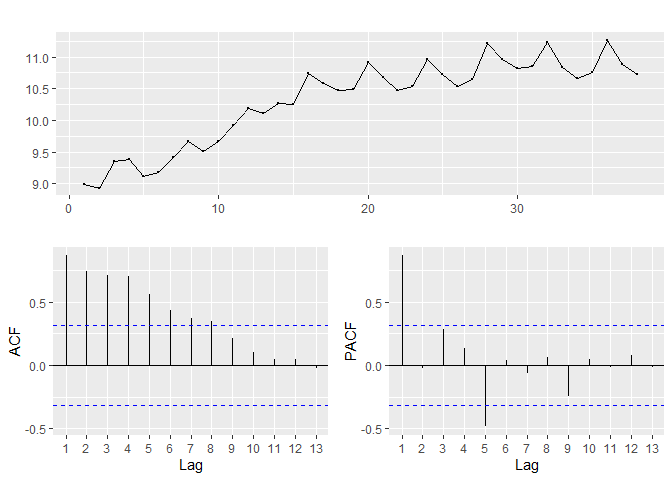

```r
ggtsdisplay(zVentas_log)
```

Nos piden que dejemos fuera las ventas de 2017, por lo que tendremos que omitir 3 observaciones de los datos (que son las del primer, segundo y tercer trimestre de dicho año).

```r
obs_omit <- 3 #Quitamos los 3 de 2017.

num_obs <- length(zVentas_log)

muestra <- window(zVentas_log,
                  start = index(zVentas_log[1]),
                  end = index(zVentas_log[num_obs - obs_omit ]))

# Que coja de zVentas todo menos los 3 últimos datos.
```

```r
fit1 <- auto.arima(muestra, lambda = 0)

knitr :: kable(summary(fit1))
```

```
## Series: muestra
## ARIMA(0,1,0)(0,1,0)[4]
## Box Cox transformation: lambda= 0
##
## sigma^2 estimated as 0.0001455:  log likelihood=90.04
## AIC=-178.08   AICc=-177.94   BIC=-176.68
##
## Training set error measures:
##                        ME      RMSE        MAE         MPE      MAPE      MASE
## Training set -0.009433358 0.1149941 0.08310241 -0.08075189 0.8077781 0.3390024
##                    ACF1
## Training set -0.1045467
```

|  | ME | RMSE | MAE | MPE | MAPE | MASE | ACF1 |
| --- | --- | --- | --- | --- | --- | --- | --- |
| Training set | -0.0094334 | 0.1149941 | 0.0831024 | -0.0807519 | 0.8077781 | 0.3390024 | -0.1045467 |

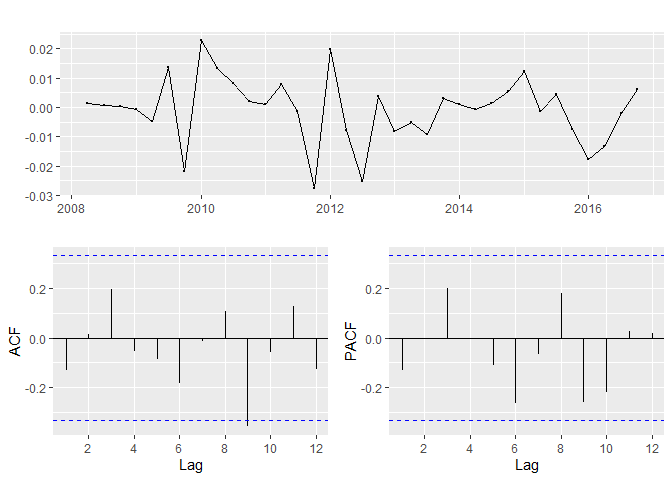

```r
ggtsdisplay(fit1$residuals)
```

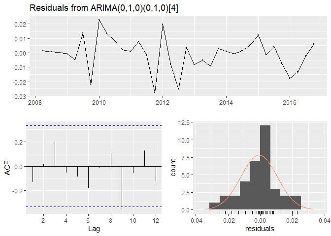

```
##
##  Ljung-Box test
##
## data:  Residuals from ARIMA(0,1,0)(0,1,0)[4]
## Q* = 4.1574, df = 7, p-value = 0.7615
##
## Model df: 0.   Total lags used: 7
```

```r
checkresiduals(fit1)
```

El modelo ARIMA que nos plantea R automáticamente no es autoregresivo ni presenta media móvil, por lo que tampoco esperaremos unos buenos resultados en nuestra predicción a partir de este mdodelo.

Por otro lado, la prueba de Ljung-Box presenta un $p_{value} = 0.7615$, lo que nos lleva a discernir que no podemos rechazar la hipótesis nula de que los datos **no presentan autocorrelación**, y por tanto, podríamos considerarlo como *ruido blanco* (error de media nula y varianza constante).

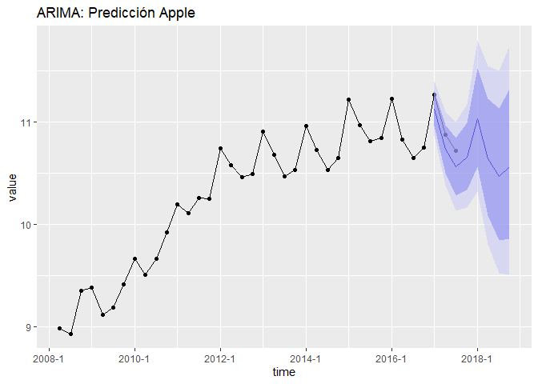

```r
fventas.arima <- forecast(fit1)

ggplot(df_new_log) +
  geom_point(aes(x = time, y = value)) +
  geom_line(aes(x = time, y = value)) +
  geom_forecast(fventas.arima, alpha = 0.5) +
  ggtitle("ARIMA: Predicción Apple")
```

```r
fventas.arima
```

```
##         Point Forecast     Lo 80    Hi 80     Lo 95    Hi 95
## 2017 Q1       11.13163 10.960855 11.30507 10.871514 11.39797
## 2017 Q2       10.73641 10.504213 10.97374 10.383335 11.10149
## 2017 Q3       10.56101 10.281957 10.84764 10.137232 11.00250
## 2017 Q4       10.66097 10.336364 10.99576 10.168550 11.17723
## 2018 Q1       11.03456 10.562433 11.52780 10.320736 11.79776
## 2018 Q2       10.64279 10.087791 11.22832  9.805807 11.55121
## 2018 Q3       10.46892  9.841112 11.13677  9.524159 11.50739
## 2018 Q4       10.56800  9.862005 11.32454  9.507570 11.74671
```

### Modelos ETS:

```r
modelo_ets <- ets(muestra)

ventas.ets <- forecast(modelo_ets)

summary(ventas.ets)
```

```
##
## Forecast method: ETS(M,A,A)
##
## Model Information:
## ETS(M,A,A)
##
## Call:
##  ets(y = muestra)
##
##   Smoothing parameters:
##     alpha = 0.4924
##     beta  = 0.3676
##     gamma = 0.5076
##
##   Initial states:
##     l = 9.0376
##     b = 0.0906
##     s = 0.1881 0.0807 -0.2048 -0.064
##
##   sigma:  0.0117
##
##         AIC        AICc         BIC
## -14.9459243  -7.7459243  -0.9477917
##
## Error measures:
##                        ME      RMSE        MAE         MPE      MAPE      MASE
## Training set -0.006606452 0.1059325 0.08553984 -0.06269475 0.8397395 0.3489455
##                     ACF1
## Training set 0.007074111
##
## Forecasts:
##         Point Forecast     Lo 80    Hi 80     Lo 95    Hi 95
## 2017 Q1       11.11778 10.950534 11.28502 10.862000 11.37356
## 2017 Q2       10.82187 10.604626 11.03912 10.489623 11.15412
## 2017 Q3       10.69711 10.401017 10.99319 10.244277 11.14993
## 2017 Q4       10.77713 10.381404 11.17286 10.171919 11.38234
## 2018 Q1       11.14016 10.570250 11.71007 10.268556 12.01177
## 2018 Q2       10.84425 10.161066 11.52744  9.799408 11.88910
## 2018 Q3       10.71949  9.906558 11.53242  9.476220 11.96276
## 2018 Q4       10.79951  9.843115 11.75591  9.336827 12.26220
```

```r
knitr :: kable(summary(modelo_ets))
```

```
## ETS(M,A,A)
##
## Call:
##  ets(y = muestra)
##
##   Smoothing parameters:
##     alpha = 0.4924
##     beta  = 0.3676
##     gamma = 0.5076
##
##   Initial states:
##     l = 9.0376
##     b = 0.0906
##     s = 0.1881 0.0807 -0.2048 -0.064
##
##   sigma:  0.0117
##
##         AIC        AICc         BIC
## -14.9459243  -7.7459243  -0.9477917
##
## Training set error measures:
##                        ME      RMSE        MAE         MPE      MAPE      MASE
## Training set -0.006606452 0.1059325 0.08553984 -0.06269475 0.8397395 0.3489455
##                     ACF1
## Training set 0.007074111
```

|  | ME | RMSE | MAE | MPE | MAPE | MASE | ACF1 |
| --- | --- | --- | --- | --- | --- | --- | --- |
| Training set | -0.0066065 | 0.1059325 | 0.0855398 | -0.0626947 | 0.8397395 | 0.3489455 | 0.0070741 |

Vemos que presenta un $RMSE = 0.106$ y un $MAPE = 0.839$. Si lo comparamos con lo obtenido en el caso anterior, para el modelo ARIMA, observamos que el RMSE es menor que en ese caso (recordemos que tenía $RMSE = 0.115$), pero un MAPE superior (el anterior modelo presentaba $MAPE = 0.808$). Esto nos presenta la disyuntiva de si deberíamos considerar uno u otro para la predicción.

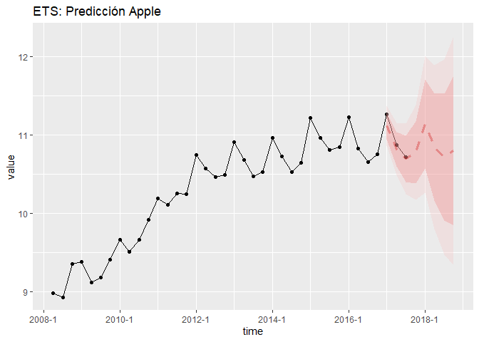

```r
ggplot(df_new_log) +
  geom_point(aes(x = time, y = value)) +
  geom_line(aes(x = time, y = value)) +
  geom_forecast(ventas.ets, alpha = 0.3, lwd = 1.2, lty = 2, color = "red") +
  ggtitle("ETS: Predicción Apple")
```

```r
pred <- as.data.frame(matrix(c(exp(ventas.ets$mean[1:obs_omit]),
                               exp(fventas.arima$mean[1:obs_omit]),
                               zVentas[(num_obs - obs_omit + 1):num_obs]),
                             ncol = 3),
                      row.names(c("Q1 2017", "Q2 2017", "Q3")))

names(pred) <- c("Predicción ETS", "Predicción ARIMA", "Real")

kable(pred)
```

| Predicción ETS | Predicción ARIMA | Real |
| --- | --- | --- |
| 67358.17 | 68297.69 | 78351 |
| 50104.74 | 46000.64 | 52896 |
| 44227.64 | 38600.07 | 45408 |

## Conclusiones

Si tomamos una gráfica en la que se vean los datos de los trimestres de 2018 “a posteriori”, veremos que las ventas (y los beneficios) han continuado subiendo, con lo que ambos modelos estimados hubiesen llevado a error.

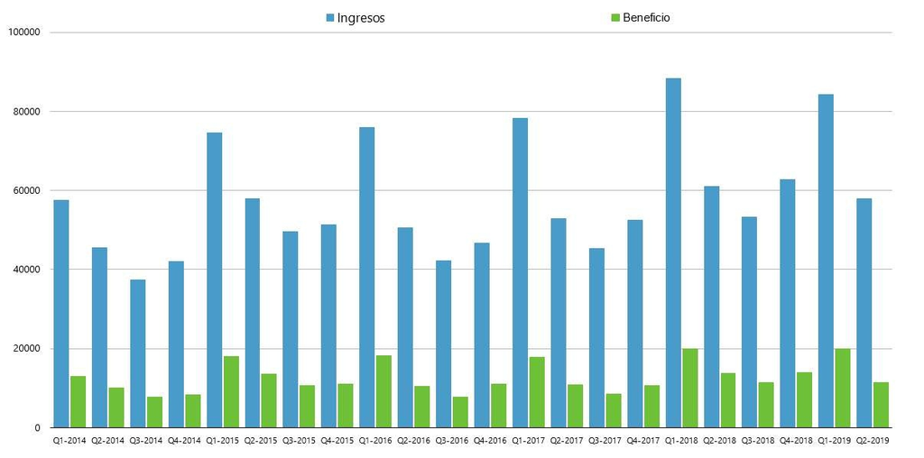